# EcoEncontros seminar series data

# EcoEncontros Seminar

Talks from EcoEncontros Seminar series at the Graduate Program of Ecology at the University of São Paulo (PPGE-USP), Brazil.

See file `metadata.txt`, in folder `data` for more description and details of the dataset.

Reading and summarising data:

```r
data1 <- read.table(here("data_raw", "presentations_PPGE_2008-2019.csv"), sep=",",
                   header=T, as.is=T)
data1$date <- dmy(data1$date)
data1$year <- year(data1$date)
skimr::skim(data1)
```

Data summary

| Name | data1 |
| --- | --- |
| Number of rows | 344 |
| Number of columns | 31 |
| _______________________ |  |
| Column type frequency: |  |
| character | 15 |
| Date | 1 |
| numeric | 15 |
| ________________________ |  |
| Group variables | None |

**Variable type: character**

| skim_variable | n_missing | complete_rate | min | max | empty | n_unique | whitespace |
| --- | --- | --- | --- | --- | --- | --- | --- |
| gender | 2 | 0.99 | 1 | 1 | 0 | 2 | 0 |
| title_original | 7 | 0.98 | 11 | 218 | 0 | 329 | 0 |
| title_language | 7 | 0.98 | 2 | 4 | 0 | 3 | 0 |
| title_english | 13 | 0.96 | 11 | 201 | 0 | 325 | 0 |
| abstract_original | 104 | 0.70 | 302 | 3078 | 0 | 236 | 0 |
| abstract_language | 104 | 0.70 | 2 | 4 | 0 | 3 | 0 |
| abstract_english | 104 | 0.70 | 303 | 3566 | 0 | 236 | 0 |
| department | 10 | 0.97 | 1 | 11 | 0 | 7 | 0 |
| institute | 6 | 0.98 | 0 | 47 | 1 | 15 | 0 |
| university | 4 | 0.99 | 3 | 47 | 0 | 96 | 0 |
| country | 2 | 0.99 | 3 | 13 | 0 | 23 | 0 |
| position | 6 | 0.98 | 6 | 17 | 0 | 7 | 0 |
| position_cat | 6 | 0.98 | 6 | 9 | 0 | 4 | 0 |
| origin | 2 | 0.99 | 2 | 11 | 0 | 6 | 0 |
| obs | 0 | 1.00 | 0 | 62 | 331 | 7 | 0 |

**Variable type: Date**

| skim_variable | n_missing | complete_rate | min | max | median | n_unique |
| --- | --- | --- | --- | --- | --- | --- |
| date | 0 | 1 | 2008-04-29 | 2019-12-12 | 2014-09-21 | 319 |

**Variable type: numeric**

| skim_variable | n_missing | complete_rate | mean | sd | p0 | p25 | p50 | p75 | p100 | hist |
| --- | --- | --- | --- | --- | --- | --- | --- | --- | --- | --- |
| id | 0 | 1.00 | 165.09 | 91.60 | 1.0 | 86.75 | 171.50 | 241.25 | 320 | ▆▆▆▇▇ |
| code_speaker | 0 | 1.00 | 145.98 | 86.47 | 1.0 | 69.75 | 145.50 | 223.00 | 292 | ▇▇▆▇▇ |
| audience_n | 0 | 1.00 | 21.68 | 11.85 | 4.0 | 14.00 | 20.00 | 27.00 | 101 | ▇▃▁▁▁ |
| audience_female | 3 | 0.99 | 12.01 | 7.00 | 2.0 | 7.00 | 11.00 | 15.00 | 57 | ▇▃▁▁▁ |
| audience_male | 3 | 0.99 | 9.54 | 5.62 | 0.0 | 6.00 | 9.00 | 12.00 | 46 | ▇▅▁▁▁ |
| audience_NA | 3 | 0.99 | 0.05 | 0.30 | 0.0 | 0.00 | 0.00 | 0.00 | 4 | ▇▁▁▁▁ |
| total_citation_n | 254 | 0.26 | 5468.91 | 6014.07 | 40.0 | 1313.75 | 3387.00 | 7170.00 | 34832 | ▇▂▁▁▁ |
| h_index | 254 | 0.26 | 31.37 | 17.33 | 2.0 | 19.00 | 28.50 | 41.00 | 90 | ▆▇▃▂▁ |
| i10_index | 254 | 0.26 | 62.14 | 46.80 | 1.0 | 28.25 | 55.00 | 78.75 | 265 | ▇▆▂▁▁ |
| most_cited_n | 254 | 0.26 | 363.54 | 476.59 | 12.0 | 93.75 | 187.50 | 461.25 | 3152 | ▇▁▁▁▁ |
| citation_cum | 254 | 0.26 | 2169.32 | 2800.19 | 17.0 | 304.50 | 971.50 | 2709.50 | 12466 | ▇▂▁▁▁ |
| years_career | 254 | 0.26 | 12.30 | 5.62 | 2.0 | 8.00 | 12.00 | 16.00 | 27 | ▆▇▇▃▂ |
| nature_index_count | 250 | 0.27 | 277.35 | 291.72 | 1.0 | 77.50 | 282.00 | 282.00 | 1699 | ▇▁▁▁▁ |
| nature_index_share | 250 | 0.27 | 71.19 | 117.56 | 0.1 | 13.25 | 53.64 | 53.64 | 763 | ▇▁▁▁▁ |
| year | 0 | 1.00 | 2014.10 | 3.27 | 2008.0 | 2012.00 | 2014.00 | 2017.00 | 2019 | ▅▆▆▆▇ |

**For ALL analyses:** Excluding special events as round tables and discussions not related to a project or study presented by someone.

```r
IDs <- c(90, 154, 170, 211, 212, 230, 244, 250, 289, 319)
data_all <- data1 %>% filter(!id %in% IDs)
```

Including varible to indicated the affirmative actions period:

```r
data_all$affirm_action <- ifelse(data_all$year<2018,"before", "after")
data_all$affirm_action <- fct_relevel(data_all$affirm_action,"before", "after")
```

There were 256 seminars before and 71 after the affirmative actions.

# Population data from the Graduate Program PPGE-USP

Data from 2008 to 2019.

Number of students, post-docs and professors in the PPGE-USP per gender and year.

```r
pop <- read.table(here("data_raw", "pop_PPGE_2008-2019.csv"), sep=",",
                   header=T, as.is=T) %>%
  mutate(total = total_F +total_M)
pop.year <- pop %>% mutate(propFyear = total_F/(total_M+total_F)) %>%
  dplyr::select(year, propFyear)

pop2 <- pop %>%
  pivot_longer(2:7, names_to=c("category","gender"), values_to="N",
               names_sep = "_") %>%
  pivot_wider(names_from = "gender", values_from="N") %>%
  mutate(propFtotal = F/total,
         propFcat = F/(F+M),
         ratioFcat = F/M) %>%
  dplyr::select(year, category, total, total_F, total_M, propFtotal,F,M,
                propFcat, ratioFcat)
```

Over all years

```r
pop2 %>% group_by(category) %>% summarise(F=sum(F), M=sum(M),
                                          prop.F = sum(F)/(sum(M)+ sum(F))) %>%
  kable(digits=2)
```

| category | F | M | prop.F |
| --- | --- | --- | --- |
| postdoc | 72 | 97 | 0.43 |
| professor | 56 | 74 | 0.43 |
| student | 603 | 394 | 0.60 |

Average over all years

```r
pop2 %>% group_by(category) %>% summarise(mean.propF=mean(propFcat),
                                          sd.propF = sd(propFcat)) %>%
  kable(digits=2)
```

| category | mean.propF | sd.propF |
| --- | --- | --- |
| postdoc | 0.48 | 0.18 |
| professor | 0.38 | 0.15 |
| student | 0.61 | 0.06 |

PPGE-USP population by gender:

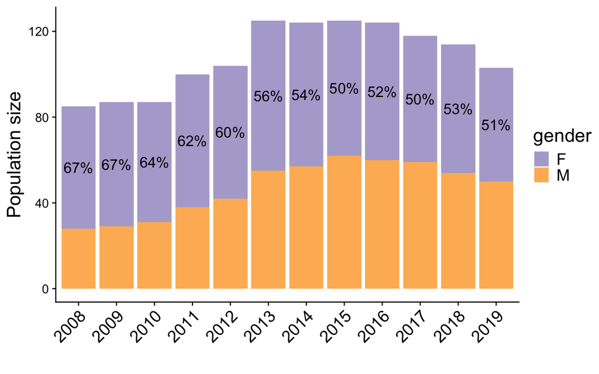

PPGE-USP population size by gender and position and year:

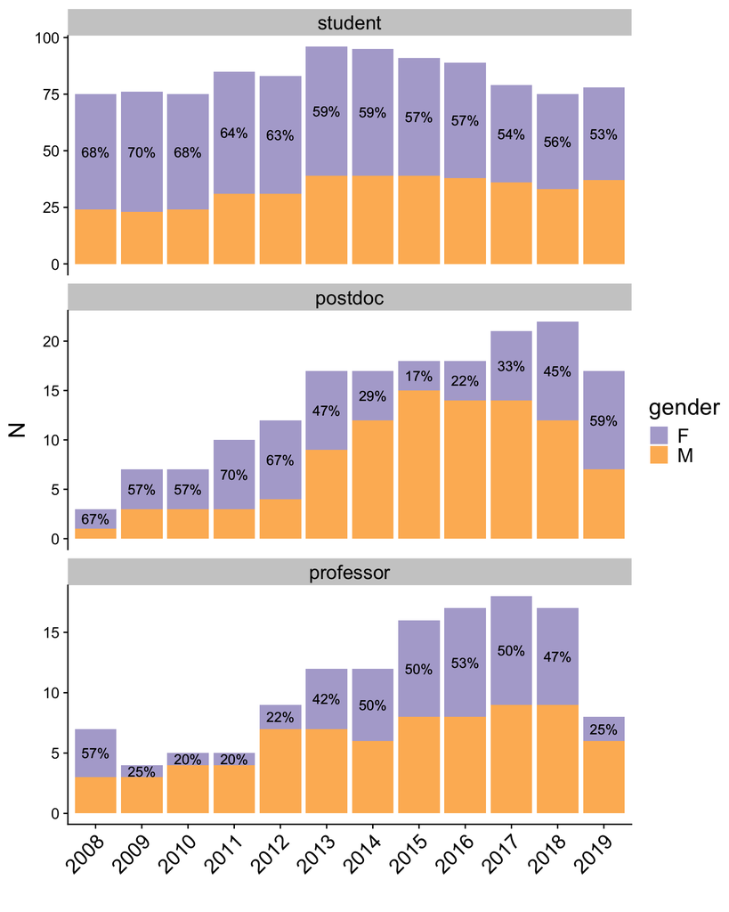

# Data description

Descriptive totals: From 344 talks in 12 years, we used 327 as we excluded special seminars and round tables.

In total, 56% of the talks were given by men (n=184) and 44% by women (n=143).

```r
dim(data_all)
```

```
## [1] 327  32
```

```r
data_all %>% tabyl(gender) %>% kable()
```

| gender | n | percent |
| --- | --- | --- |
| F | 143 | 0.4373089 |
| M | 184 | 0.5626911 |

# Speakers data

Proportion and number of male and female speakers per academic position.

```r
data_p <- data_all %>% filter(position_cat != "others")
data_p$position_cat <- fct_relevel(data_p$position_cat, "student",
                                 "postdoc","professor")
```

Excluding talks from non-academic professionals. N = 320.

```r
data_p %>% tabyl(position_cat)
```

```
##  position_cat   n  percent
##       student 167 0.521875
##       postdoc  57 0.178125
##     professor  96 0.300000
```

Proportion and number (in parenthesis) of female (F) and male (M) speakers per academic position.

| position_cat | F | M |
| --- | --- | --- |
| student | 53% (89) | 47% (78) |
| postdoc | 44% (25) | 56% (32) |
| professor | 25% (24) | 75% (72) |

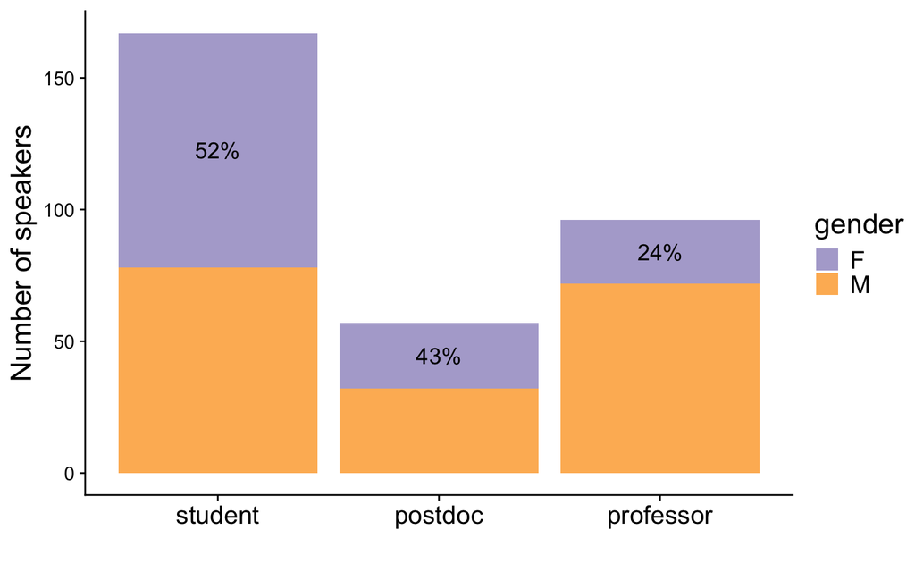

Variation in years:

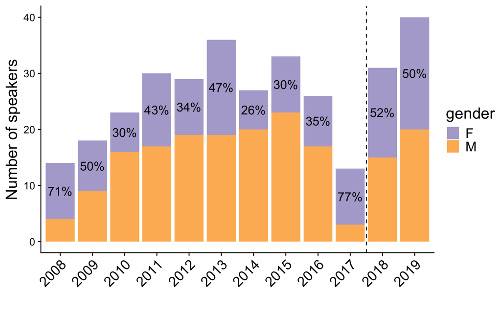

### Origin of the speakers

There were 136 (42%) talks given by people from the PPGE population.

Including talks from the Institute of Biosciences, USP, there were 173 (54%).

### Comparing proportions of female speakers in the seminar and in the PPGE population by position.

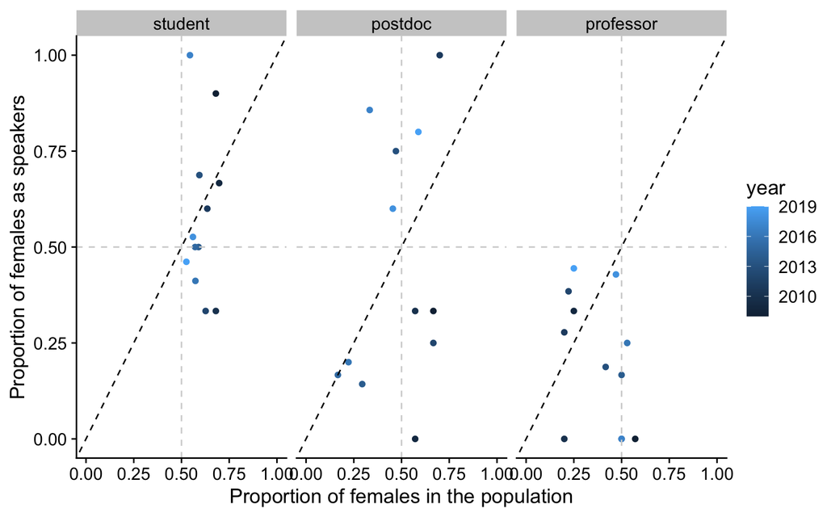

Relationship between the proportion of females in the PPGE population in each category of academic position in each year (x axis) and the proportion of female speakers in the same category and year. Horizontal and vertical gray dashed lines are the 50% of each proportion and diagonal black dashed line indicates where the propotions are similar.

## Only speakers from the PPGE community

```r
datappge <- data_p %>% filter(department == "Ecologia", institute == "IB",
                            university == "USP")
```

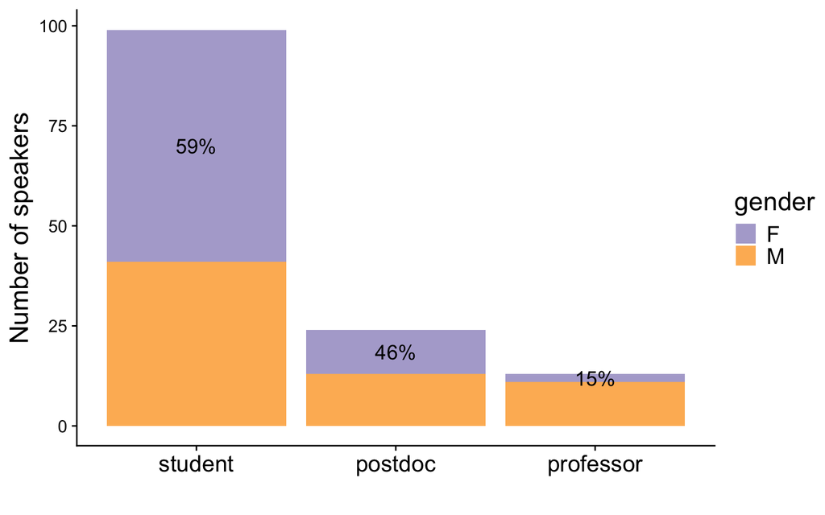

Variation in years:

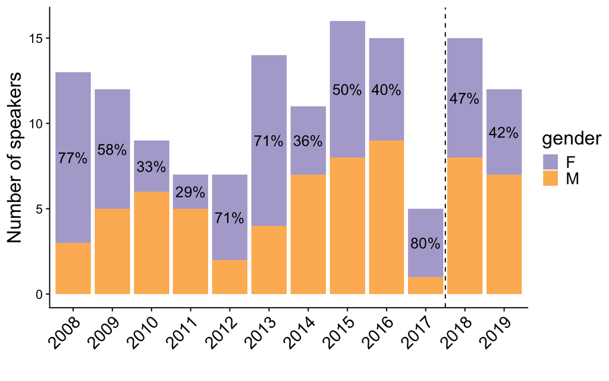

# Audience data

Excluding talks from non-academic professionals.

Excluding seminars with more than one speaker:

```r
events <- data_p %>% count(id) %>% filter(n>1)
data_a <- data_p %>% filter(!id %in% events$id,
                        !is.na(audience_n))
```

There were 298 talks with information about the number of attendees.

```r
data_a %>% group_by(position_cat,gender) %>% summarise(N=n(),
                                                       min=min(audience_n),
                                                       mean=mean(audience_n),
                                                       sd = sd(audience_n),
                                                       median=median(audience_n),
                                                       max=max(audience_n)) %>%
  kable(digits=2, caption = "Summary data of the audience (number of attendees per gender and academic level.")
```

Summary data of the audience (number of attendees per gender and academic level.

| position_cat | gender | N | min | mean | sd | median | max |
| --- | --- | --- | --- | --- | --- | --- | --- |
| student | F | 77 | 4 | 17.58 | 6.69 | 18.0 | 36 |
| student | M | 70 | 6 | 19.83 | 8.20 | 19.0 | 44 |
| postdoc | F | 23 | 5 | 19.52 | 10.34 | 18.0 | 50 |
| postdoc | M | 32 | 5 | 18.97 | 8.78 | 18.0 | 43 |
| professor | F | 24 | 4 | 21.54 | 9.78 | 21.0 | 40 |
| professor | M | 72 | 5 | 29.51 | 16.46 | 26.5 | 101 |

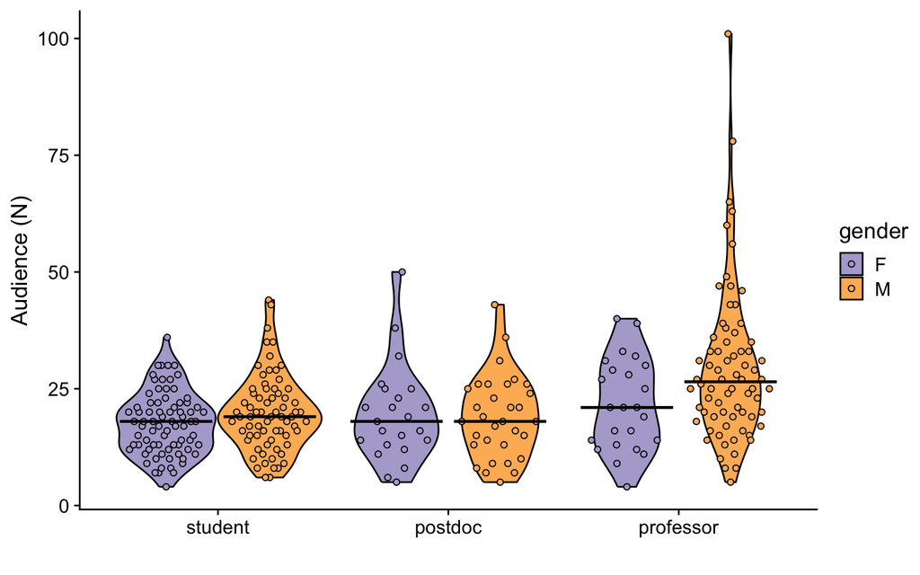

Looking for possible influence of the speakers origin (inside and outside PPGE) in the audience.

```r
data_a$ib <- ifelse(data_a$origin == "IB", "inside", "outside")
data_a %>% tabyl(gender,ib, position_cat) %>% adorn_percentages("row") %>%
  adorn_pct_formatting(digits = 0) %>%
  adorn_ns()
```

```
## $professor
##  gender   inside  outside
##       F 33%  (8) 67% (16)
##       M 25% (18) 75% (54)
##
## $student
##  gender   inside  outside
##       F 68% (52) 32% (25)
##       M 59% (41) 41% (29)
##
## $postdoc
##  gender   inside  outside
##       F 65% (15) 35%  (8)
##       M 62% (20) 38% (12)
```

```r
table(data_a$gender,data_a$ib)
```

```
##
##     inside outside
##   F     75      49
##   M     79      95
```

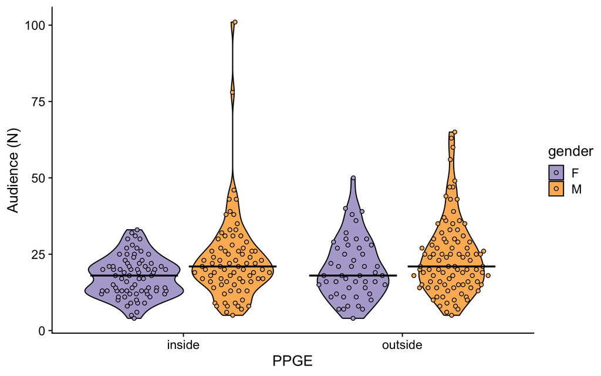

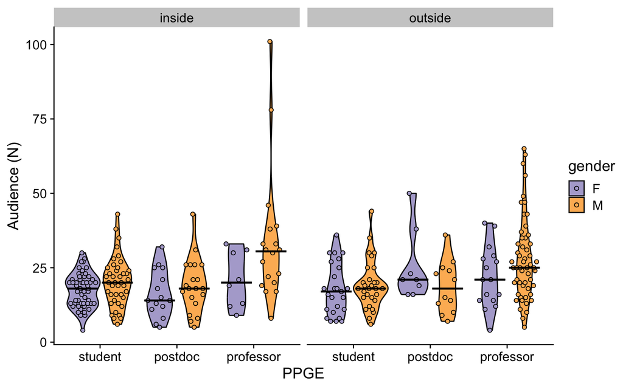

Looking for possible influence of the speaker origing (Brazil or abroad).

```r
data_a$brazilian <- ifelse(data_a$country == "Brasil", "yes", "no")
table(data_a$gender,data_a$brazilian)
```

```
##
##      no yes
##   F  22 102
##   M  50 124
```

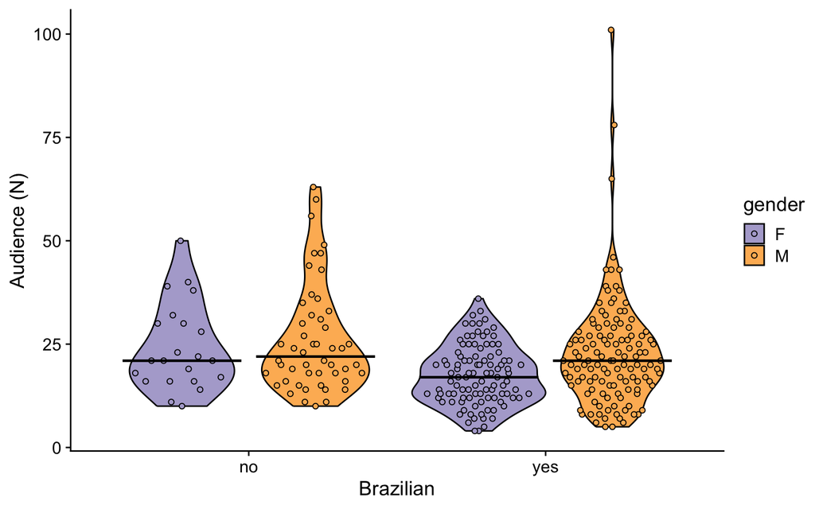

# Text analysis data

Excluding talks without title

```r
data_t <- data_all %>% filter(!is.na(title_english))
```

There were 320 talks with title information.

# Saving processed data

PPGE population data

```r
save(pop2, file = here("data_clean", "data_pop_ppge.Rdata"))
```

Data for the proportion of female speakers

```r
save(data_p, file = here("data_clean", "data_proportion.Rdata"))
```

Data for the audience of the talks

```r
save(data_a, file = here("data_clean", "data_audience.Rdata"))
```

Data for the text analysis

```r
save(data_t, file = here("data_clean", "data_title.Rdata"))
```